# Predict Bike Sharing Demand with AutoGluon Template

## Project: Predict Bike Sharing Demand with AutoGluon

This notebook is a template with each step that you need to complete for the project.

Please fill in your code where there are explicit `?` markers in the notebook. You are welcome to add more cells and code as you see fit.

Once you have completed all the code implementations, please export your notebook as a HTML file so the reviews can view your code. Make sure you have all outputs correctly outputted.

`File-> Export Notebook As... -> Export Notebook as HTML`

There is a writeup to complete as well after all code implememtation is done. Please answer all questions and attach the necessary tables and charts. You can complete the writeup in either markdown or PDF.

Completing the code template and writeup template will cover all of the rubric points for this project.

The rubric contains "Stand Out Suggestions" for enhancing the project beyond the minimum requirements. The stand out suggestions are optional. If you decide to pursue the "stand out suggestions", you can include the code in this notebook and also discuss the results in the writeup file.

## Step 1: Create an account with Kaggle

### Create Kaggle Account and download API key

Below is example of steps to get the API username and key. Each student will have their own username and key.

1. Open account settings.

2. Scroll down to API and click Create New API Token.

3. Open up `kaggle.json` and use the username and key.


## Step 2: Download the Kaggle dataset using the kaggle python library

### Open up Sagemaker Studio and use starter template

1. Notebook should be using a `ml.t3.medium` instance (2 vCPU + 4 GiB)
2. Notebook should be using kernal: `Python 3 (MXNet 1.8 Python 3.7 CPU Optimized)`

### Install packages

```python
!pip install -U pip
!pip install -U setuptools wheel
!pip install -U "mxnet<2.0.0" bokeh==2.0.1
!pip install autogluon --no-cache-dir
# Without --no-cache-dir, smaller aws instances may have trouble installing
```

[output not shown]

[output cut: 70 more lines]

[output not shown]

### Setup Kaggle API Key

```python
# create the .kaggle directory and an empty kaggle.json file
!mkdir -p /root/.kaggle
!touch /root/.kaggle/kaggle.json
!chmod 600 /root/.kaggle/kaggle.json
```

```python
# Fill in your user name and key from creating the kaggle account and API token file
import json
kaggle_username = "USERNAME"
kaggle_key = "USERKEY"

# Save API token the kaggle.json file
with open("/root/.kaggle/kaggle.json", "w") as f:
    f.write(json.dumps({"username": kaggle_username, "key": kaggle_key}))
```

### Download and explore dataset

### Go to the bike sharing demand competition and agree to the terms

```python
# Download the dataset, it will be in a .zip file so you'll need to unzip it as well.
!kaggle competitions download -c bike-sharing-demand
# If you already downloaded it you can use the -o command to overwrite the file
!unzip -o bike-sharing-demand.zip
```

```
Downloading bike-sharing-demand.zip to /kaggle/working
Archive:  bike-sharing-demand.zip
  inflating: sampleSubmission.csv
  inflating: test.csv
  inflating: train.csv
```

```python
import copy
import pandas as pd
from autogluon.tabular import TabularPredictor
```

```python
# Create the train dataset in pandas by reading the csv
# Set the parsing of the datetime column so you can use some of the `dt` features in pandas later
train = pd.read_csv("/kaggle/input/bike-sharing-demand/train.csv", parse_dates=['datetime'])
train.head()
```

|  | datetime | season | holiday | workingday | weather | temp | atemp | humidity | windspeed | casual | registered | count |
| --- | --- | --- | --- | --- | --- | --- | --- | --- | --- | --- | --- | --- |
| 0 | 2011-01-01 00:00:00 | 1 | 0 | 0 | 1 | 9.84 | 14.395 | 81 | 0.0 | 3 | 13 | 16 |
| 1 | 2011-01-01 01:00:00 | 1 | 0 | 0 | 1 | 9.02 | 13.635 | 80 | 0.0 | 8 | 32 | 40 |
| 2 | 2011-01-01 02:00:00 | 1 | 0 | 0 | 1 | 9.02 | 13.635 | 80 | 0.0 | 5 | 27 | 32 |
| 3 | 2011-01-01 03:00:00 | 1 | 0 | 0 | 1 | 9.84 | 14.395 | 75 | 0.0 | 3 | 10 | 13 |
| 4 | 2011-01-01 04:00:00 | 1 | 0 | 0 | 1 | 9.84 | 14.395 | 75 | 0.0 | 0 | 1 | 1 |

```python
# Simple output of the train dataset to view some of the min/max/varition of the dataset features.
train.describe()
```

|  | season | holiday | workingday | weather | temp | atemp | humidity | windspeed | casual | registered | count |
| --- | --- | --- | --- | --- | --- | --- | --- | --- | --- | --- | --- |
| count | 10886.000000 | 10886.000000 | 10886.000000 | 10886.000000 | 10886.00000 | 10886.000000 | 10886.000000 | 10886.000000 | 10886.000000 | 10886.000000 | 10886.000000 |
| mean | 2.506614 | 0.028569 | 0.680875 | 1.418427 | 20.23086 | 23.655084 | 61.886460 | 12.799395 | 36.021955 | 155.552177 | 191.574132 |
| std | 1.116174 | 0.166599 | 0.466159 | 0.633839 | 7.79159 | 8.474601 | 19.245033 | 8.164537 | 49.960477 | 151.039033 | 181.144454 |
| min | 1.000000 | 0.000000 | 0.000000 | 1.000000 | 0.82000 | 0.760000 | 0.000000 | 0.000000 | 0.000000 | 0.000000 | 1.000000 |
| 25% | 2.000000 | 0.000000 | 0.000000 | 1.000000 | 13.94000 | 16.665000 | 47.000000 | 7.001500 | 4.000000 | 36.000000 | 42.000000 |
| 50% | 3.000000 | 0.000000 | 1.000000 | 1.000000 | 20.50000 | 24.240000 | 62.000000 | 12.998000 | 17.000000 | 118.000000 | 145.000000 |
| 75% | 4.000000 | 0.000000 | 1.000000 | 2.000000 | 26.24000 | 31.060000 | 77.000000 | 16.997900 | 49.000000 | 222.000000 | 284.000000 |
| max | 4.000000 | 1.000000 | 1.000000 | 4.000000 | 41.00000 | 45.455000 | 100.000000 | 56.996900 | 367.000000 | 886.000000 | 977.000000 |

```python
# Create the test pandas dataframe in pandas by reading the csv, remember to parse the datetime!
test = pd.read_csv("/kaggle/input/bike-sharing-demand/test.csv", parse_dates=['datetime'])
test.head()
```

|  | datetime | season | holiday | workingday | weather | temp | atemp | humidity | windspeed |
| --- | --- | --- | --- | --- | --- | --- | --- | --- | --- |
| 0 | 2011-01-20 00:00:00 | 1 | 0 | 1 | 1 | 10.66 | 11.365 | 56 | 26.0027 |
| 1 | 2011-01-20 01:00:00 | 1 | 0 | 1 | 1 | 10.66 | 13.635 | 56 | 0.0000 |
| 2 | 2011-01-20 02:00:00 | 1 | 0 | 1 | 1 | 10.66 | 13.635 | 56 | 0.0000 |
| 3 | 2011-01-20 03:00:00 | 1 | 0 | 1 | 1 | 10.66 | 12.880 | 56 | 11.0014 |
| 4 | 2011-01-20 04:00:00 | 1 | 0 | 1 | 1 | 10.66 | 12.880 | 56 | 11.0014 |

```python
# Same thing as train and test dataset
submission = pd.read_csv("/kaggle/input/bike-sharing-demand/sampleSubmission.csv", parse_dates=['datetime'])
submission.head()
```

|  | datetime | count |
| --- | --- | --- |
| 0 | 2011-01-20 00:00:00 | 0 |
| 1 | 2011-01-20 01:00:00 | 0 |
| 2 | 2011-01-20 02:00:00 | 0 |
| 3 | 2011-01-20 03:00:00 | 0 |
| 4 | 2011-01-20 04:00:00 | 0 |

## Step 3: Train a model using AutoGluon’s Tabular Prediction

Requirements:

- We are prediting `count`, so it is the label we are setting.
- Ignore `casual` and `registered` columns as they are also not present in the test dataset.
- Use the `root_mean_squared_error` as the metric to use for evaluation.
- Set a time limit of 10 minutes (600 seconds).
- Use the preset `best_quality` to focus on creating the best model.

```python
predictor = TabularPredictor(
    label='count',
    eval_metric='root_mean_squared_error'
    ).fit(
        train_data=train.loc[:, ~train.columns.isin(['casual', 'registered'])],
        time_limit=600,
        presets='best_quality'
)
```

```
No path specified. Models will be saved in: "AutogluonModels/ag-20230530_045720/"
Presets specified: ['best_quality']
Stack configuration (auto_stack=True): num_stack_levels=1, num_bag_folds=8, num_bag_sets=20
Beginning AutoGluon training ... Time limit = 600s
AutoGluon will save models to "AutogluonModels/ag-20230530_045720/"
AutoGluon Version:  0.7.0
Python Version:     3.10.10
Operating System:   Linux
Platform Machine:   x86_64
Platform Version:   #1 SMP Sat May 20 10:48:19 UTC 2023
Train Data Rows:    10886
Train Data Columns: 9
Label Column: count
Preprocessing data ...
AutoGluon infers your prediction problem is: 'regression' (because dtype of label-column == int and many unique label-values observed).
	Label info (max, min, mean, stddev): (977, 1, 191.57413, 181.14445)
	If 'regression' is not the correct problem_type, please manually specify the problem_type parameter during predictor init (You may specify problem_type as one of: ['binary', 'multiclass', 'regression'])
Using Feature Generators to preprocess the data ...
Fitting AutoMLPipelineFeatureGenerator...
	Available Memory:                    32252.75 MB
	Train Data (Original)  Memory Usage: 0.78 MB (0.0% of available memory)
	Inferring data type of each feature based on column values. Set feature_metadata_in to manually specify special dtypes of the features.
	Stage 1 Generators:
		Fitting AsTypeFeatureGenerator...
			Note: Converting 2 features to boolean dtype as they only contain 2 unique values.
	Stage 2 Generators:
		Fitting FillNaFeatureGenerator...
	Stage 3 Generators:
		Fitting IdentityFeatureGenerator...
		Fitting DatetimeFeatureGenerator...
	Stage 4 Generators:
		Fitting DropUniqueFeatureGenerator...
	Types of features in original data (raw dtype, special dtypes):
		('datetime', []) : 1 | ['datetime']
		('float', [])    : 3 | ['temp', 'atemp', 'windspeed']
		('int', [])      : 5 | ['season', 'holiday', 'workingday', 'weather', 'humidity']
	Types of features in processed data (raw dtype, special dtypes):
		('float', [])                : 3 | ['temp', 'atemp', 'windspeed']
		('int', [])                  : 3 | ['season', 'weather', 'humidity']
		('int', ['bool'])            : 2 | ['holiday', 'workingday']
```

[output cut: 45 more lines]

```
	-60.6739	 = Validation score   (-root_mean_squared_error)
	120.64s	 = Training   runtime
	15.76s	 = Validation runtime
Fitting model: LightGBM_BAG_L2 ... Training model for up to 40.92s of the 40.9s of remaining time.
	Fitting 8 child models (S1F1 - S1F8) | Fitting with ParallelLocalFoldFittingStrategy
	-54.6729	 = Validation score   (-root_mean_squared_error)
	50.42s	 = Training   runtime
	2.47s	 = Validation runtime
Completed 1/20 k-fold bagging repeats ...
Fitting model: WeightedEnsemble_L3 ... Training model for up to 360.0s of the -31.09s of remaining time.
	-54.6545	 = Validation score   (-root_mean_squared_error)
	0.23s	 = Training   runtime
	0.0s	 = Validation runtime
AutoGluon training complete, total runtime = 631.35s ... Best model: "WeightedEnsemble_L3"
TabularPredictor saved. To load, use: predictor = TabularPredictor.load("AutogluonModels/ag-20230530_045720/")
```

### Review AutoGluon's training run with ranking of models that did the best.

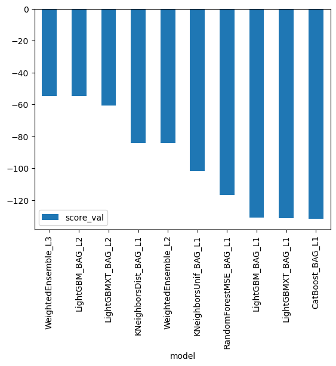

```python
predictor.leaderboard(silent=True).plot(kind="bar", x="model", y="score_val")
```

```python
predictor.fit_summary()
```

```
*** Summary of fit() ***
Estimated performance of each model:
                    model   score_val  pred_time_val    fit_time  pred_time_val_marginal  fit_time_marginal  stack_level  can_infer  fit_order
0     WeightedEnsemble_L3  -54.654525      68.656847  515.063628                0.000984           0.233090            3       True         10
1         LightGBM_BAG_L2  -54.672870      52.892894  394.193869                2.465005          50.416390            2       True          9
2       LightGBMXT_BAG_L2  -60.673936      66.190857  464.414148               15.762969         120.636669            2       True          8
3   KNeighborsDist_BAG_L1  -84.175461       0.060224    0.021571                0.060224           0.021571            1       True          2
4     WeightedEnsemble_L2  -84.175461       0.061188    0.568775                0.000964           0.547204            2       True          7
5   KNeighborsUnif_BAG_L1 -101.644380       0.269245    0.837554                0.269245           0.837554            1       True          1
6  RandomForestMSE_BAG_L1 -116.548359       0.812572   22.522126                0.812572          22.522126            1       True          5
7         LightGBM_BAG_L1 -131.054162       8.859172   58.658911                8.859172          58.658911            1       True          4
8       LightGBMXT_BAG_L1 -131.460909      39.823449  149.467138               39.823449         149.467138            1       True          3
9         CatBoost_BAG_L1 -131.699596       0.603226  112.270179                0.603226         112.270179            1       True          6
Number of models trained: 10
Types of models trained:
{'StackerEnsembleModel_RF', 'StackerEnsembleModel_LGB', 'StackerEnsembleModel_KNN', 'WeightedEnsembleModel', 'StackerEnsembleModel_CatBoost'}
Bagging used: True  (with 8 folds)
Multi-layer stack-ensembling used: True  (with 3 levels)
Feature Metadata (Processed):
(raw dtype, special dtypes):
('float', [])                : 3 | ['temp', 'atemp', 'windspeed']
('int', [])                  : 3 | ['season', 'weather', 'humidity']
('int', ['bool'])            : 2 | ['holiday', 'workingday']
('int', ['datetime_as_int']) : 5 | ['datetime', 'datetime.year', 'datetime.month', 'datetime.day', 'datetime.dayofweek']
*** End of fit() summary ***
```

```
{'model_types': {'KNeighborsUnif_BAG_L1': 'StackerEnsembleModel_KNN',
  'KNeighborsDist_BAG_L1': 'StackerEnsembleModel_KNN',
  'LightGBMXT_BAG_L1': 'StackerEnsembleModel_LGB',
  'LightGBM_BAG_L1': 'StackerEnsembleModel_LGB',
  'RandomForestMSE_BAG_L1': 'StackerEnsembleModel_RF',
  'CatBoost_BAG_L1': 'StackerEnsembleModel_CatBoost',
  'WeightedEnsemble_L2': 'WeightedEnsembleModel',
  'LightGBMXT_BAG_L2': 'StackerEnsembleModel_LGB',
  'LightGBM_BAG_L2': 'StackerEnsembleModel_LGB',
  'WeightedEnsemble_L3': 'WeightedEnsembleModel'},
 'model_performance': {'KNeighborsUnif_BAG_L1': -101.64437969927306,
  'KNeighborsDist_BAG_L1': -84.17546135232182,
  'LightGBMXT_BAG_L1': -131.46090891834504,
  'LightGBM_BAG_L1': -131.054161598899,
  'RandomForestMSE_BAG_L1': -116.54835939455667,
  'CatBoost_BAG_L1': -131.69959604587447,
  'WeightedEnsemble_L2': -84.17546135232182,
  'LightGBMXT_BAG_L2': -60.67393564054444,
  'LightGBM_BAG_L2': -54.67287010857454,
  'WeightedEnsemble_L3': -54.65452539714687},
 'model_best': 'WeightedEnsemble_L3',
 'model_paths': {'KNeighborsUnif_BAG_L1': 'AutogluonModels/ag-20230530_045720/models/KNeighborsUnif_BAG_L1/',
  'KNeighborsDist_BAG_L1': 'AutogluonModels/ag-20230530_045720/models/KNeighborsDist_BAG_L1/',
  'LightGBMXT_BAG_L1': 'AutogluonModels/ag-20230530_045720/models/LightGBMXT_BAG_L1/',
  'LightGBM_BAG_L1': 'AutogluonModels/ag-20230530_045720/models/LightGBM_BAG_L1/',
  'RandomForestMSE_BAG_L1': 'AutogluonModels/ag-20230530_045720/models/RandomForestMSE_BAG_L1/',
  'CatBoost_BAG_L1': 'AutogluonModels/ag-20230530_045720/models/CatBoost_BAG_L1/',
  'WeightedEnsemble_L2': 'AutogluonModels/ag-20230530_045720/models/WeightedEnsemble_L2/',
  'LightGBMXT_BAG_L2': 'AutogluonModels/ag-20230530_045720/models/LightGBMXT_BAG_L2/',
  'LightGBM_BAG_L2': 'AutogluonModels/ag-20230530_045720/models/LightGBM_BAG_L2/',
  'WeightedEnsemble_L3': 'AutogluonModels/ag-20230530_045720/models/WeightedEnsemble_L3/'},
 'model_fit_times': {'KNeighborsUnif_BAG_L1': 0.8375539779663086,
  'KNeighborsDist_BAG_L1': 0.02157115936279297,
  'LightGBMXT_BAG_L1': 149.46713757514954,
  'LightGBM_BAG_L1': 58.65891075134277,
  'RandomForestMSE_BAG_L1': 22.522125959396362,
  'CatBoost_BAG_L1': 112.270179271698,
  'WeightedEnsemble_L2': 0.5472040176391602,
  'LightGBMXT_BAG_L2': 120.63666939735413,
  'LightGBM_BAG_L2': 50.41639041900635,
```

[output cut: 76 more lines]

```
 7                8.859172          58.658911            1       True
 8               39.823449         149.467138            1       True
 9                0.603226         112.270179            1       True

    fit_order
 0         10
 1          9
 2          8
 3          2
 4          7
 5          1
 6          5
 7          4
 8          3
 9          6  }
```

### Create predictions from test dataset

```python
predictions = predictor.predict(test)
predictions.head()
```

```
0    37.659012
1    50.909443
2    56.604744
3    57.697338
4    59.034214
Name: count, dtype: float32
```

#### NOTE: Kaggle will reject the submission if we don't set everything to be > 0.

```python
# Describe the `predictions` series to see if there are any negative values
predictions.describe()
```

```
count    6493.000000
mean      116.653244
std       111.670380
min        -7.122203
25%        16.194124
50%        70.621170
75%       199.147476
max       459.343506
Name: count, dtype: float64
```

```python
# How many negative values do we have?
(predictions < 0).sum()
```

```
2
```

```python
# Set them to zero
predictions[predictions < 0] = 0
```

### Set predictions to submission dataframe, save, and submit

```python
submission["count"] = predictions
submission.to_csv("submission.csv", index=False)
```

```python
!kaggle competitions submit -c bike-sharing-demand -f submission.csv -m "default submission"
```

```
Successfully submitted to Bike Sharing Demand
```

#### View submission via the command line or in the web browser under the competition's page - `My Submissions`

```python
!kaggle competitions submissions -c bike-sharing-demand | tail -n +1 | head -n 6
```

```
fileName                     date                 description                                                      status    publicScore  privateScore
---------------------------  -------------------  ---------------------------------------------------------------  --------  -----------  ------------
submission.csv               2023-05-30 05:09:03  default submission                                               pending
submission_new_hpo.csv       2023-05-29 09:47:58  new features with gridsearch advance hyperparameters submission  complete  0.95464      0.95464
submission_new_hpo.csv       2023-05-29 09:12:15  new features with gridsearch advance hyperparameters submission  complete  0.93949      0.93949
submission_new_hpo.csv       2023-05-29 09:00:51  new features with advance hyperparameters submission             complete  0.60226      0.60226
```

## Step 4: Exploratory Data Analysis and Creating an additional feature

- Any additional feature will do, but a great suggestion would be to separate out the datetime into hour, day, or month parts.

```
array([[<Axes: title={'center': 'datetime'}>,
        <Axes: title={'center': 'season'}>,
        <Axes: title={'center': 'holiday'}>],
       [<Axes: title={'center': 'workingday'}>,
        <Axes: title={'center': 'weather'}>,
        <Axes: title={'center': 'temp'}>],
       [<Axes: title={'center': 'atemp'}>,
        <Axes: title={'center': 'humidity'}>,
        <Axes: title={'center': 'windspeed'}>],
       [<Axes: title={'center': 'casual'}>,
        <Axes: title={'center': 'registered'}>,
        <Axes: title={'center': 'count'}>]], dtype=object)
```

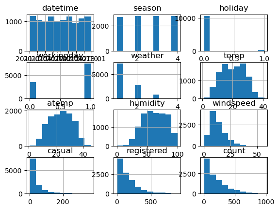

```python
# Create a histogram of all features to show the distribution of each one relative to the data. This is part of the exploritory data analysis
train.hist()
```

```python
# create a new feature
train['hour'] = train["datetime"].dt.hour
train.drop(columns=['datetime'], inplace=True)
test['hour'] = test["datetime"].dt.hour
test.drop(columns=['datetime'], inplace=True)
```

## Make category types for these so models know they are not just numbers

- AutoGluon originally sees these as ints, but in reality they are int representations of a category.
- Setting the dtype to category will classify these as categories in AutoGluon.

```python
train["season"] = train["season"].astype("category")
train["weather"] = train["weather"].astype("category")
test["season"] = test["season"].astype("category")
test["weather"] = test["weather"].astype("category")
```

```python
# View are new feature
train.head()
```

|  | season | holiday | workingday | weather | temp | atemp | humidity | windspeed | casual | registered | count | hour |
| --- | --- | --- | --- | --- | --- | --- | --- | --- | --- | --- | --- | --- |
| 0 | 1 | 0 | 0 | 1 | 9.84 | 14.395 | 81 | 0.0 | 3 | 13 | 16 | 0 |
| 1 | 1 | 0 | 0 | 1 | 9.02 | 13.635 | 80 | 0.0 | 8 | 32 | 40 | 1 |
| 2 | 1 | 0 | 0 | 1 | 9.02 | 13.635 | 80 | 0.0 | 5 | 27 | 32 | 2 |
| 3 | 1 | 0 | 0 | 1 | 9.84 | 14.395 | 75 | 0.0 | 3 | 10 | 13 | 3 |
| 4 | 1 | 0 | 0 | 1 | 9.84 | 14.395 | 75 | 0.0 | 0 | 1 | 1 | 4 |

```
array([[<Axes: title={'center': 'holiday'}>,
        <Axes: title={'center': 'workingday'}>,
        <Axes: title={'center': 'temp'}>],
       [<Axes: title={'center': 'atemp'}>,
        <Axes: title={'center': 'humidity'}>,
        <Axes: title={'center': 'windspeed'}>],
       [<Axes: title={'center': 'casual'}>,
        <Axes: title={'center': 'registered'}>,
        <Axes: title={'center': 'count'}>],
       [<Axes: title={'center': 'hour'}>, <Axes: >, <Axes: >]],
      dtype=object)
```

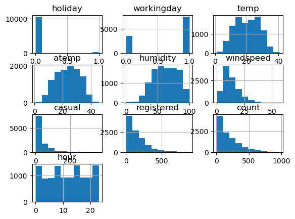

```python
# View histogram of all features again now with the hour feature
train.hist()
```

## Step 5: Rerun the model with the same settings as before, just with more features

```python
predictor_new_features = TabularPredictor(
    label='count',
    eval_metric='root_mean_squared_error'
    ).fit(
        train_data=train.loc[:, ~train.columns.isin(['casual', 'registered'])],
        time_limit=600,
        presets='best_quality'
)
```

```
No path specified. Models will be saved in: "AutogluonModels/ag-20230530_050911/"
Presets specified: ['best_quality']
Stack configuration (auto_stack=True): num_stack_levels=1, num_bag_folds=8, num_bag_sets=20
Beginning AutoGluon training ... Time limit = 600s
AutoGluon will save models to "AutogluonModels/ag-20230530_050911/"
AutoGluon Version:  0.7.0
Python Version:     3.10.10
Operating System:   Linux
Platform Machine:   x86_64
Platform Version:   #1 SMP Sat May 20 10:48:19 UTC 2023
Train Data Rows:    10886
Train Data Columns: 9
Label Column: count
Preprocessing data ...
AutoGluon infers your prediction problem is: 'regression' (because dtype of label-column == int and many unique label-values observed).
	Label info (max, min, mean, stddev): (977, 1, 191.57413, 181.14445)
	If 'regression' is not the correct problem_type, please manually specify the problem_type parameter during predictor init (You may specify problem_type as one of: ['binary', 'multiclass', 'regression'])
Using Feature Generators to preprocess the data ...
Fitting AutoMLPipelineFeatureGenerator...
	Available Memory:                    31362.04 MB
	Train Data (Original)  Memory Usage: 0.63 MB (0.0% of available memory)
	Inferring data type of each feature based on column values. Set feature_metadata_in to manually specify special dtypes of the features.
	Stage 1 Generators:
		Fitting AsTypeFeatureGenerator...
			Note: Converting 2 features to boolean dtype as they only contain 2 unique values.
	Stage 2 Generators:
		Fitting FillNaFeatureGenerator...
	Stage 3 Generators:
		Fitting IdentityFeatureGenerator...
		Fitting CategoryFeatureGenerator...
			Fitting CategoryMemoryMinimizeFeatureGenerator...
	Stage 4 Generators:
		Fitting DropUniqueFeatureGenerator...
	Types of features in original data (raw dtype, special dtypes):
		('category', []) : 2 | ['season', 'weather']
		('float', [])    : 3 | ['temp', 'atemp', 'windspeed']
		('int', [])      : 4 | ['holiday', 'workingday', 'humidity', 'hour']
	Types of features in processed data (raw dtype, special dtypes):
		('category', [])  : 2 | ['season', 'weather']
		('float', [])     : 3 | ['temp', 'atemp', 'windspeed']
```

[output cut: 50 more lines]

```
	Fitting 8 child models (S1F1 - S1F8) | Fitting with ParallelLocalFoldFittingStrategy
	-64.5321	 = Validation score   (-root_mean_squared_error)
	43.77s	 = Training   runtime
	1.32s	 = Validation runtime
Fitting model: RandomForestMSE_BAG_L2 ... Training model for up to 42.3s of the 42.29s of remaining time.
	-64.3651	 = Validation score   (-root_mean_squared_error)
	41.97s	 = Training   runtime
	0.86s	 = Validation runtime
Completed 1/20 k-fold bagging repeats ...
Fitting model: WeightedEnsemble_L3 ... Training model for up to 360.0s of the -1.33s of remaining time.
	-63.7525	 = Validation score   (-root_mean_squared_error)
	0.26s	 = Training   runtime
	0.0s	 = Validation runtime
AutoGluon training complete, total runtime = 601.63s ... Best model: "WeightedEnsemble_L3"
TabularPredictor saved. To load, use: predictor = TabularPredictor.load("AutogluonModels/ag-20230530_050911/")
```

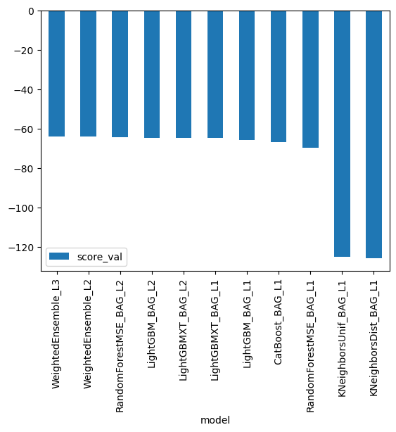

```python
predictor_new_features.leaderboard(silent=True).plot(kind="bar", x="model", y="score_val")
```

```python
predictor_new_features.fit_summary()
```

```
*** Summary of fit() ***
Estimated performance of each model:
                     model   score_val  pred_time_val    fit_time  pred_time_val_marginal  fit_time_marginal  stack_level  can_infer  fit_order
0      WeightedEnsemble_L3  -63.752485      71.903755  495.491820                0.000977           0.260614            3       True         11
1      WeightedEnsemble_L2  -63.771076      67.724080  349.318788                0.001041           0.663891            2       True          7
2   RandomForestMSE_BAG_L2  -64.365066      68.742835  390.666630                0.861310          41.974387            2       True         10
3          LightGBM_BAG_L2  -64.532119      69.203269  392.467184                1.321743          43.774941            2       True          9
4        LightGBMXT_BAG_L2  -64.550680      69.719725  409.481877                1.838200          60.789634            2       True          8
5        LightGBMXT_BAG_L1  -64.565891      54.381951  130.982672               54.381951         130.982672            1       True          3
6          LightGBM_BAG_L1  -65.677254      12.065628   57.943107               12.065628          57.943107            1       True          4
7          CatBoost_BAG_L1  -66.769672       0.417298  144.438601                0.417298         144.438601            1       True          6
8   RandomForestMSE_BAG_L1  -69.553854       0.858162   15.290517                0.858162          15.290517            1       True          5
9    KNeighborsUnif_BAG_L1 -124.894772       0.079325    0.018703                0.079325           0.018703            1       True          1
10   KNeighborsDist_BAG_L1 -125.637130       0.079161    0.018642                0.079161           0.018642            1       True          2
Number of models trained: 11
Types of models trained:
{'StackerEnsembleModel_RF', 'StackerEnsembleModel_LGB', 'StackerEnsembleModel_KNN', 'WeightedEnsembleModel', 'StackerEnsembleModel_CatBoost'}
Bagging used: True  (with 8 folds)
Multi-layer stack-ensembling used: True  (with 3 levels)
Feature Metadata (Processed):
(raw dtype, special dtypes):
('category', [])  : 2 | ['season', 'weather']
('float', [])     : 3 | ['temp', 'atemp', 'windspeed']
('int', [])       : 2 | ['humidity', 'hour']
('int', ['bool']) : 2 | ['holiday', 'workingday']
*** End of fit() summary ***
```

```
{'model_types': {'KNeighborsUnif_BAG_L1': 'StackerEnsembleModel_KNN',
  'KNeighborsDist_BAG_L1': 'StackerEnsembleModel_KNN',
  'LightGBMXT_BAG_L1': 'StackerEnsembleModel_LGB',
  'LightGBM_BAG_L1': 'StackerEnsembleModel_LGB',
  'RandomForestMSE_BAG_L1': 'StackerEnsembleModel_RF',
  'CatBoost_BAG_L1': 'StackerEnsembleModel_CatBoost',
  'WeightedEnsemble_L2': 'WeightedEnsembleModel',
  'LightGBMXT_BAG_L2': 'StackerEnsembleModel_LGB',
  'LightGBM_BAG_L2': 'StackerEnsembleModel_LGB',
  'RandomForestMSE_BAG_L2': 'StackerEnsembleModel_RF',
  'WeightedEnsemble_L3': 'WeightedEnsembleModel'},
 'model_performance': {'KNeighborsUnif_BAG_L1': -124.8947723031866,
  'KNeighborsDist_BAG_L1': -125.6371299995347,
  'LightGBMXT_BAG_L1': -64.56589067040215,
  'LightGBM_BAG_L1': -65.67725376948735,
  'RandomForestMSE_BAG_L1': -69.55385431777009,
  'CatBoost_BAG_L1': -66.76967222884153,
  'WeightedEnsemble_L2': -63.77107567012062,
  'LightGBMXT_BAG_L2': -64.5506797841005,
  'LightGBM_BAG_L2': -64.53211934796111,
  'RandomForestMSE_BAG_L2': -64.36506573286617,
  'WeightedEnsemble_L3': -63.75248465736684},
 'model_best': 'WeightedEnsemble_L3',
 'model_paths': {'KNeighborsUnif_BAG_L1': 'AutogluonModels/ag-20230530_050911/models/KNeighborsUnif_BAG_L1/',
  'KNeighborsDist_BAG_L1': 'AutogluonModels/ag-20230530_050911/models/KNeighborsDist_BAG_L1/',
  'LightGBMXT_BAG_L1': 'AutogluonModels/ag-20230530_050911/models/LightGBMXT_BAG_L1/',
  'LightGBM_BAG_L1': 'AutogluonModels/ag-20230530_050911/models/LightGBM_BAG_L1/',
  'RandomForestMSE_BAG_L1': 'AutogluonModels/ag-20230530_050911/models/RandomForestMSE_BAG_L1/',
  'CatBoost_BAG_L1': 'AutogluonModels/ag-20230530_050911/models/CatBoost_BAG_L1/',
  'WeightedEnsemble_L2': 'AutogluonModels/ag-20230530_050911/models/WeightedEnsemble_L2/',
  'LightGBMXT_BAG_L2': 'AutogluonModels/ag-20230530_050911/models/LightGBMXT_BAG_L2/',
  'LightGBM_BAG_L2': 'AutogluonModels/ag-20230530_050911/models/LightGBM_BAG_L2/',
  'RandomForestMSE_BAG_L2': 'AutogluonModels/ag-20230530_050911/models/RandomForestMSE_BAG_L2/',
  'WeightedEnsemble_L3': 'AutogluonModels/ag-20230530_050911/models/WeightedEnsemble_L3/'},
 'model_fit_times': {'KNeighborsUnif_BAG_L1': 0.018703460693359375,
  'KNeighborsDist_BAG_L1': 0.018642187118530273,
  'LightGBMXT_BAG_L1': 130.98267197608948,
  'LightGBM_BAG_L1': 57.94310712814331,
  'RandomForestMSE_BAG_L1': 15.29051661491394,
  'CatBoost_BAG_L1': 144.43860149383545,
```

[output cut: 89 more lines]

```
 9                 0.079325           0.018703            1       True
 10                0.079161           0.018642            1       True

     fit_order
 0          11
 1           7
 2          10
 3           9
 4           8
 5           3
 6           4
 7           6
 8           5
 9           1
 10          2  }
```

```python
# Remember to set all negative values to zero
predictions_new_features = predictor_new_features.predict(test)
predictions_new_features[predictions_new_features < 0] = 0
```

```python
predictions_new_features.describe()
```

```
count    6493.000000
mean      187.959991
std       166.208313
min         4.181672
25%        46.379059
50%       150.193329
75%       279.232239
max       777.574951
Name: count, dtype: float64
```

```python
# Same submitting predictions
submission_new_features = copy.deepcopy(submission)
submission_new_features["count"] = predictions_new_features
submission_new_features.to_csv("submission_new_features.csv", index=False)
```

```python
!kaggle competitions submit -c bike-sharing-demand -f submission_new_features.csv -m "new features submission"
```

```
Successfully submitted to Bike Sharing Demand
```

```python
!kaggle competitions submissions -c bike-sharing-demand | tail -n +1 | head -n 6
```

```
fileName                     date                 description                                                      status    publicScore  privateScore
---------------------------  -------------------  ---------------------------------------------------------------  --------  -----------  ------------
submission_new_features.csv  2023-05-30 05:20:04  new features submission                                          complete  0.48821      0.48821
submission.csv               2023-05-30 05:09:03  default submission                                               complete  1.89050      1.89050
submission_new_hpo.csv       2023-05-29 09:47:58  new features with gridsearch advance hyperparameters submission  complete  0.95464      0.95464
submission_new_hpo.csv       2023-05-29 09:12:15  new features with gridsearch advance hyperparameters submission  complete  0.93949      0.93949
```

## Step 6: Hyper parameter optimization

- There are many options for hyper parameter optimization.
- Options are to change the AutoGluon higher level parameters or the individual model hyperparameters.
- The hyperparameters of the models themselves that are in AutoGluon. Those need the `hyperparameter` and `hyperparameter_tune_kwargs` arguments.

```python
predictor_new_hpo = TabularPredictor(
    label='count',
    eval_metric='root_mean_squared_error'
    ).fit(
        train_data=train.loc[:, ~train.columns.isin(['casual', 'registered'])],
        time_limit=600,
        presets='best_quality',
        hyperparameters='light'
)
```

```
No path specified. Models will be saved in: "AutogluonModels/ag-20230530_052007/"
Presets specified: ['best_quality']
Stack configuration (auto_stack=True): num_stack_levels=1, num_bag_folds=8, num_bag_sets=20
Beginning AutoGluon training ... Time limit = 600s
AutoGluon will save models to "AutogluonModels/ag-20230530_052007/"
AutoGluon Version:  0.7.0
Python Version:     3.10.10
Operating System:   Linux
Platform Machine:   x86_64
Platform Version:   #1 SMP Sat May 20 10:48:19 UTC 2023
Train Data Rows:    10886
Train Data Columns: 9
Label Column: count
Preprocessing data ...
AutoGluon infers your prediction problem is: 'regression' (because dtype of label-column == int and many unique label-values observed).
	Label info (max, min, mean, stddev): (977, 1, 191.57413, 181.14445)
	If 'regression' is not the correct problem_type, please manually specify the problem_type parameter during predictor init (You may specify problem_type as one of: ['binary', 'multiclass', 'regression'])
Using Feature Generators to preprocess the data ...
Fitting AutoMLPipelineFeatureGenerator...
	Available Memory:                    31325.89 MB
	Train Data (Original)  Memory Usage: 0.63 MB (0.0% of available memory)
	Inferring data type of each feature based on column values. Set feature_metadata_in to manually specify special dtypes of the features.
	Stage 1 Generators:
		Fitting AsTypeFeatureGenerator...
			Note: Converting 2 features to boolean dtype as they only contain 2 unique values.
	Stage 2 Generators:
		Fitting FillNaFeatureGenerator...
	Stage 3 Generators:
		Fitting IdentityFeatureGenerator...
		Fitting CategoryFeatureGenerator...
			Fitting CategoryMemoryMinimizeFeatureGenerator...
	Stage 4 Generators:
		Fitting DropUniqueFeatureGenerator...
	Types of features in original data (raw dtype, special dtypes):
		('category', []) : 2 | ['season', 'weather']
		('float', [])    : 3 | ['temp', 'atemp', 'windspeed']
		('int', [])      : 4 | ['holiday', 'workingday', 'humidity', 'hour']
	Types of features in processed data (raw dtype, special dtypes):
		('category', [])  : 2 | ['season', 'weather']
		('float', [])     : 3 | ['temp', 'atemp', 'windspeed']
```

[output cut: 47 more lines]

```
	-64.3281	 = Validation score   (-root_mean_squared_error)
	28.63s	 = Training   runtime
	0.67s	 = Validation runtime
Fitting model: CatBoost_BAG_L2 ... Training model for up to 16.42s of the 16.4s of remaining time.
	Fitting 8 child models (S1F1 - S1F8) | Fitting with ParallelLocalFoldFittingStrategy
	-67.0847	 = Validation score   (-root_mean_squared_error)
	34.64s	 = Training   runtime
	0.6s	 = Validation runtime
Completed 1/20 k-fold bagging repeats ...
Fitting model: WeightedEnsemble_L3 ... Training model for up to 360.0s of the -36.4s of remaining time.
	-63.7779	 = Validation score   (-root_mean_squared_error)
	0.41s	 = Training   runtime
	0.0s	 = Validation runtime
AutoGluon training complete, total runtime = 636.84s ... Best model: "WeightedEnsemble_L3"
TabularPredictor saved. To load, use: predictor = TabularPredictor.load("AutogluonModels/ag-20230530_052007/")
```

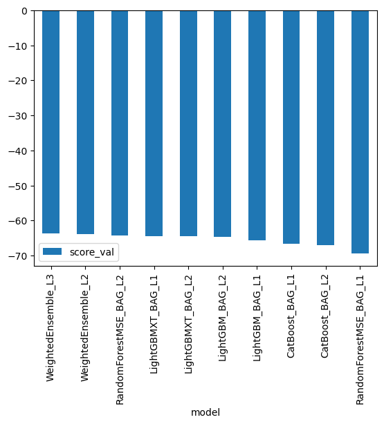

```python
predictor_new_hpo.leaderboard(silent=True).plot(kind="bar", x="model", y="score_val")
```

```python
predictor_new_hpo.fit_summary()
```

```
*** Summary of fit() ***
Estimated performance of each model:
                    model  score_val  pred_time_val    fit_time  pred_time_val_marginal  fit_time_marginal  stack_level  can_infer  fit_order
0     WeightedEnsemble_L3 -63.777874      72.410020  498.460679                0.000989           0.406928            3       True         10
1     WeightedEnsemble_L2 -63.804331      65.419007  348.817381                0.001525           0.369635            2       True          5
2  RandomForestMSE_BAG_L2 -64.328141      66.087967  377.078290                0.670485          28.630543            2       True          8
3       LightGBMXT_BAG_L1 -64.565891      50.947682  132.587641               50.947682         132.587641            1       True          1
4       LightGBMXT_BAG_L2 -64.583189      69.087296  394.233751                3.669814          45.786005            2       True          6
5         LightGBM_BAG_L2 -64.624764      67.469331  388.997101                2.051849          40.549354            2       True          7
6         LightGBM_BAG_L1 -65.677254      12.035001   60.946829               12.035001          60.946829            1       True          2
7         CatBoost_BAG_L1 -66.734190       1.616946  141.730099                1.616946         141.730099            1       True          4
8         CatBoost_BAG_L2 -67.084679      66.016882  383.087849                0.599401          34.640102            2       True          9
9  RandomForestMSE_BAG_L1 -69.420953       0.817853   13.183178                0.817853          13.183178            1       True          3
Number of models trained: 10
Types of models trained:
{'StackerEnsembleModel_LGB', 'StackerEnsembleModel_CatBoost', 'StackerEnsembleModel_RF', 'WeightedEnsembleModel'}
Bagging used: True  (with 8 folds)
Multi-layer stack-ensembling used: True  (with 3 levels)
Feature Metadata (Processed):
(raw dtype, special dtypes):
('category', [])  : 2 | ['season', 'weather']
('float', [])     : 3 | ['temp', 'atemp', 'windspeed']
('int', [])       : 2 | ['humidity', 'hour']
('int', ['bool']) : 2 | ['holiday', 'workingday']
*** End of fit() summary ***
```

```
{'model_types': {'LightGBMXT_BAG_L1': 'StackerEnsembleModel_LGB',
  'LightGBM_BAG_L1': 'StackerEnsembleModel_LGB',
  'RandomForestMSE_BAG_L1': 'StackerEnsembleModel_RF',
  'CatBoost_BAG_L1': 'StackerEnsembleModel_CatBoost',
  'WeightedEnsemble_L2': 'WeightedEnsembleModel',
  'LightGBMXT_BAG_L2': 'StackerEnsembleModel_LGB',
  'LightGBM_BAG_L2': 'StackerEnsembleModel_LGB',
  'RandomForestMSE_BAG_L2': 'StackerEnsembleModel_RF',
  'CatBoost_BAG_L2': 'StackerEnsembleModel_CatBoost',
  'WeightedEnsemble_L3': 'WeightedEnsembleModel'},
 'model_performance': {'LightGBMXT_BAG_L1': -64.56589067040215,
  'LightGBM_BAG_L1': -65.67725376948735,
  'RandomForestMSE_BAG_L1': -69.42095347152758,
  'CatBoost_BAG_L1': -66.73419034223663,
  'WeightedEnsemble_L2': -63.804330635338665,
  'LightGBMXT_BAG_L2': -64.58318928137446,
  'LightGBM_BAG_L2': -64.62476393320388,
  'RandomForestMSE_BAG_L2': -64.32814055389048,
  'CatBoost_BAG_L2': -67.08467922561928,
  'WeightedEnsemble_L3': -63.777873787647266},
 'model_best': 'WeightedEnsemble_L3',
 'model_paths': {'LightGBMXT_BAG_L1': 'AutogluonModels/ag-20230530_052007/models/LightGBMXT_BAG_L1/',
  'LightGBM_BAG_L1': 'AutogluonModels/ag-20230530_052007/models/LightGBM_BAG_L1/',
  'RandomForestMSE_BAG_L1': 'AutogluonModels/ag-20230530_052007/models/RandomForestMSE_BAG_L1/',
  'CatBoost_BAG_L1': 'AutogluonModels/ag-20230530_052007/models/CatBoost_BAG_L1/',
  'WeightedEnsemble_L2': 'AutogluonModels/ag-20230530_052007/models/WeightedEnsemble_L2/',
  'LightGBMXT_BAG_L2': 'AutogluonModels/ag-20230530_052007/models/LightGBMXT_BAG_L2/',
  'LightGBM_BAG_L2': 'AutogluonModels/ag-20230530_052007/models/LightGBM_BAG_L2/',
  'RandomForestMSE_BAG_L2': 'AutogluonModels/ag-20230530_052007/models/RandomForestMSE_BAG_L2/',
  'CatBoost_BAG_L2': 'AutogluonModels/ag-20230530_052007/models/CatBoost_BAG_L2/',
  'WeightedEnsemble_L3': 'AutogluonModels/ag-20230530_052007/models/WeightedEnsemble_L3/'},
 'model_fit_times': {'LightGBMXT_BAG_L1': 132.58764052391052,
  'LightGBM_BAG_L1': 60.946828842163086,
  'RandomForestMSE_BAG_L1': 13.183177947998047,
  'CatBoost_BAG_L1': 141.7300989627838,
  'WeightedEnsemble_L2': 0.36963486671447754,
  'LightGBMXT_BAG_L2': 45.78600478172302,
  'LightGBM_BAG_L2': 40.54935431480408,
  'RandomForestMSE_BAG_L2': 28.63054347038269,
  'CatBoost_BAG_L2': 34.64010238647461,
```

[output cut: 75 more lines]

```
 7                1.616946         141.730099            1       True
 8                0.599401          34.640102            2       True
 9                0.817853          13.183178            1       True

    fit_order
 0         10
 1          5
 2          8
 3          1
 4          6
 5          7
 6          2
 7          4
 8          9
 9          3  }
```

```python
# Remember to set all negative values to zero
predictions_new_hpo = predictor_new_hpo.predict(test)
predictions_new_hpo[predictions_new_hpo < 0] = 0
```

```python
predictions_new_hpo.describe()
```

```
count    6493.000000
mean      187.847870
std       165.558289
min         4.790408
25%        46.743046
50%       150.223785
75%       279.564240
max       777.568665
Name: count, dtype: float64
```

```python
# Same submitting predictions
submission_new_hpo = copy.deepcopy(submission)
submission_new_hpo["count"] = predictions_new_hpo
submission_new_hpo.to_csv("submission_new_hpo.csv", index=False)
```

```python
!kaggle competitions submit -c bike-sharing-demand -f submission_new_hpo.csv -m "new features with hyperparameters submission"
```

```
Successfully submitted to Bike Sharing Demand
```

```python
!kaggle competitions submissions -c bike-sharing-demand | tail -n +1 | head -n 6
```

```
fileName                     date                 description                                                      status    publicScore  privateScore
---------------------------  -------------------  ---------------------------------------------------------------  --------  -----------  ------------
submission_new_hpo.csv       2023-05-30 05:31:42  new features with hyperparameters submission                     complete  0.49440      0.49440
submission_new_features.csv  2023-05-30 05:20:04  new features submission                                          complete  0.48821      0.48821
submission.csv               2023-05-30 05:09:03  default submission                                               complete  1.89050      1.89050
submission_new_hpo.csv       2023-05-29 09:47:58  new features with gridsearch advance hyperparameters submission  complete  0.95464      0.95464
```

## Step 7: Write a Report

### Refer to the markdown file for the full report

### Creating plots and table for report

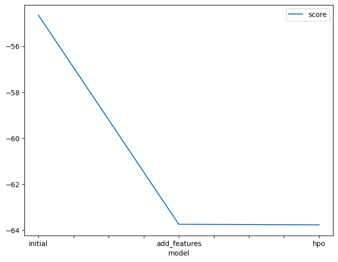

```python
# Taking the top model score from each training run and creating a line plot to show improvement
# You can create these in the notebook and save them to PNG or use some other tool (e.g. google sheets, excel)
fig = pd.DataFrame(
    {
        "model": ["initial", "add_features", "hpo"],
        "score": [-54.654525, -63.752485, -63.777874]
    }
).plot(x="model", y="score", figsize=(8, 6)).get_figure()
fig.savefig('model_train_score.png')
```

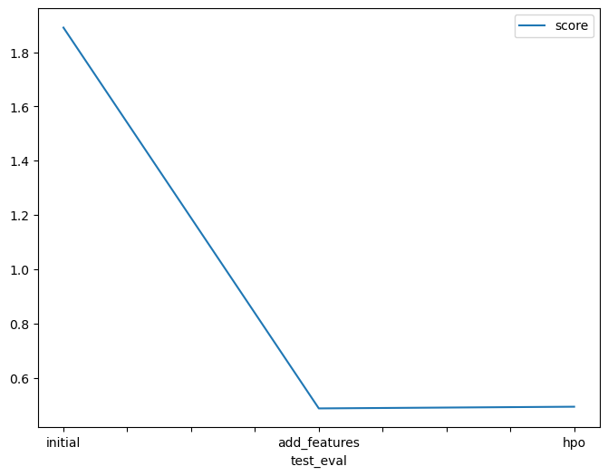

```python
# Take the 3 kaggle scores and creating a line plot to show improvement
fig = pd.DataFrame(
    {
        "test_eval": ["initial", "add_features", "hpo"],
        "score": [1.89050, 0.48821, 0.49440]
    }
).plot(x="test_eval", y="score", figsize=(8, 6)).get_figure()
fig.savefig('model_test_score.png')
```

### Hyperparameter table

```python
# The 3 hyperparameters we tuned with the kaggle score as the result
pd.DataFrame({
    "model": ["initial", "add_features", "hpo"],
    "hpo1": ['default', 'default', 'light'],
    "hpo2": ['default', 'default', 'light'],
    "hpo3": ['default', 'default', 'light'],
    "score": [1.89050, 0.48821, 0.49440]
})
```

|  | model | hpo1 | hpo2 | hpo3 | score |
| --- | --- | --- | --- | --- | --- |
| 0 | initial | default | default | default | 1.89050 |
| 1 | add_features | default | default | default | 0.48821 |
| 2 | hpo | light | light | light | 0.49440 |